# 트위터 분석

해쉬태그 키워드 중심

xwMOOC

2020-01-26

본 보고서는 [다양한 데이터 가져오기 - “트위터 데이터 과학”](https://statkclee.github.io/ingest-data/ingest-twitter-data-science.html) 웹문서를 `Makefile`을 작성하여 자동화하는 것을 재현하는 과정을 담고 있다.

# 1 트위터 데이터

가장 먼저 트위터 데이터를 가져와야 한다. 이를 위해서 `get_data.R` 스크립트에 내장된 `get_data()` 함수를 사용해서 트위터에서 데이터를 가져와서 이를 내부적으로 저장시킨다. 원래 `DT` 팩키지를 사용해서 인터랙티브하게 분석 보고서를 작성하는 것이 좋으나, `.pdf`, `.docx` 파일 출력결과를 생각해서 `kable()` 함수를 사용해서 이를 정적 문서에서도 가시성이 좋도록 표를 작업한다. `kable()` 함수가 PDF, Word 파일 생성시 표를 제대로 만들어 내지 않는 경우 `pander()`로 대신한다.

```r
library(tidyverse)
library(pander)

panderOptions('table.alignment.default', function(df)
    ifelse(sapply(df, is.numeric), 'right', 'left'))
panderOptions('table.split.table', Inf)
panderOptions('big.mark', ",")
panderOptions('keep.trailing.zeros', TRUE)

twit_df <- read_rds("data/tw_dat.rds")

twit_df %>%
  sample_n(10) %>%
  select(screen_name, created_at, text) %>%
  pander()
```

| screen_name | created_at | text |
| --- | --- | --- |
| l8ueYa8GPKaUfqh | 2020-01-22 06:30:58 | 국민 사이다 되시는 거 아님?ㅎ 답답하게 쌓인 국민들 마음 시원하게 뚫릴 듯.. #공감맨 #개념남 #백신맨 #안철수 #안철수박사 #AI #경제전문가 #교수 #의사 #러너 #안보전문가 #교육전문가 #천재 안철수, 문재인에 일침…“한 번도 경험해보지 못한 무능” https://t.co/Ba0aKyExWi |
| AI_bot_ | 2020-01-21 02:00:58 | 「 피식거려도 이해해줄수있겠지-…? 」#AI |
| Pardoe_AI | 2020-01-18 10:50:11 | 아인- 칼내려놔 #AI |
| up10tion_jing | 2020-01-25 07:03:45 | 환희 말 못알아듣는 A.I #업텐션 #up10tion #미치게해 #AI https://t.co/OMjeujyGFP |
| kanginyeol | 2020-01-20 10:07:39 | 새전북신문 [새전북만평-정윤성] 민족 대이동 앞두고… #설 #명절 #민족대이동 #돼지열병 #구제역 #ai #우한폐렴 #중국 #방역 https://t.co/jaYXTrZou5 |
| hahah_2020 | 2020-01-22 13:00:51 | ‘공정’ ‘경제’ 이어 ‘#AI’. 안철수, 카이스트 방문해 AI국가전략 경청. https://t.co/mhmJBi6xO5 ●23일 4차 산업혁명시대의 AI 비전 논의. ●기술·발전 상응하는 법·제도 방향 생각 밝힌다. ●“AI가 우리 삶 전체와 국가경쟁력을 좌우하게 될 것” ●미래 먹거리·미래 일자리 위한 ‘일하는 정치’ 언급 https://t.co/0w… |
| AI_bot_ | 2020-01-24 06:00:59 | 아인- 칼내려놔 #AI |
| kmo0707 | 2020-01-22 09:49:10 | 국민 사이다 되시는 거 아님?ㅎ 답답하게 쌓인 국민들 마음 시원하게 뚫릴 듯.. #공감맨 #개념남 #백신맨 #안철수 #안철수박사 #AI #경제전문가 #교수 #의사 #러너 #안보전문가 #교육전문가 #천재 안철수, 문재인에 일침…“한 번도 경험해보지 못한 무능” https://t.co/Ba0aKyExWi |
| minsumi77 | 2020-01-23 15:19:24 | #안철수_미래세대를_위한_프로젝트 나는 우리 미래세대를 위한 러닝5.0 프로젝트를 이미 개발하기 시작했다 #다시안철수🏃🏻‍♂️ #미래세대 #인공지능 #AI #러닝5.0 https://t.co/WTndzJGyIg |
| AI_bot_ | 2020-01-24 08:30:55 | 「 채색이 망가진 세계 안에서 아직 어린 눈에 찌른 한 송이의 붉은 장미」#AI |

# 2 트위터 추세

`graph_trend.R` 파일에 `graph_trend()` 함수를 사용해서 `twit_trend.png` 파일을 생성하여 특정 해쉬태그 트위터 데이터의 추세를 파악하고자 시각화하느 결과를 보여주는 것이 목적이다.

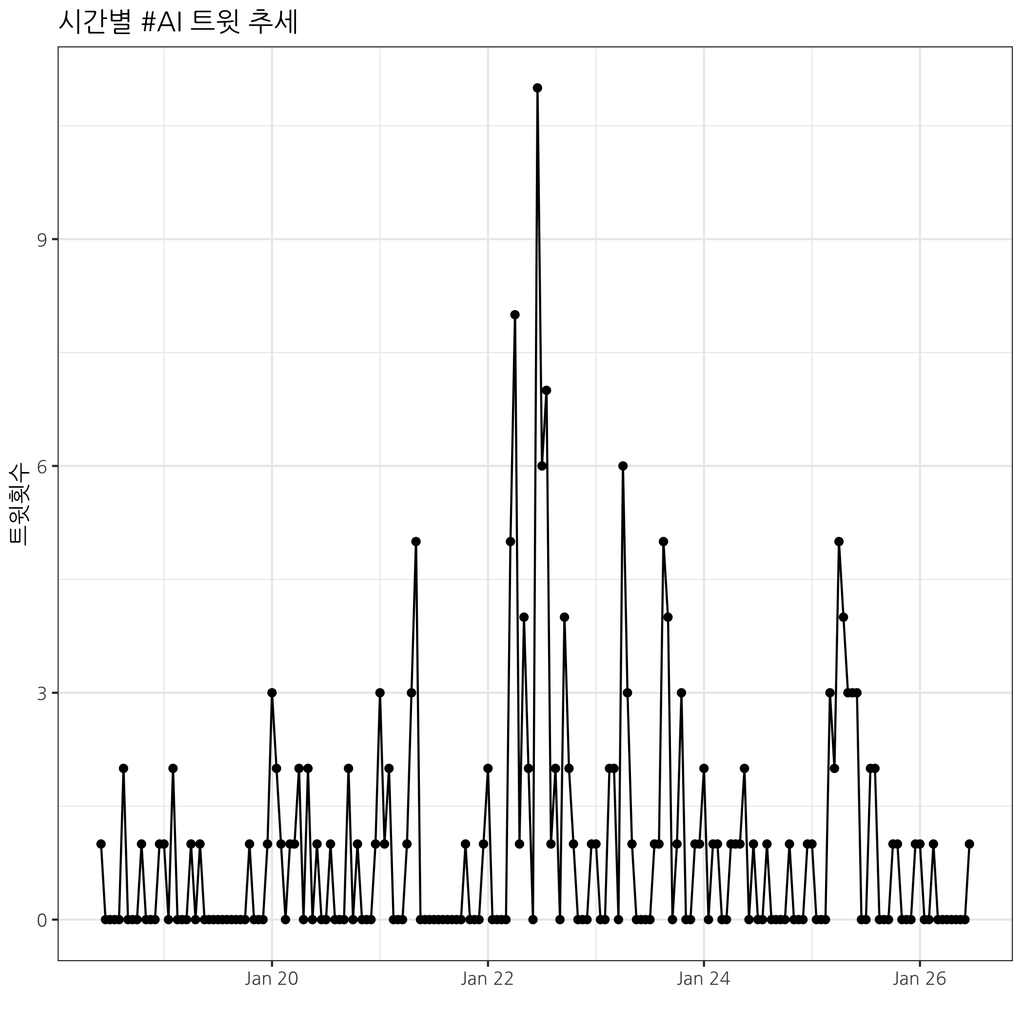

트위터 해쉬태그 추세

# 3 사용자 활동성 지표

특정 해쉬태그를 많이 언급한 사용자에 대한 기본 프로파일 정보를 `lookup_users()` 함수를 통해서 파악할 수 있고 이를 바탕으로 다음 사용자 프로파일 활동성 정보를 얻어올 수 있다.

- status
- followers
- friends
- favourites

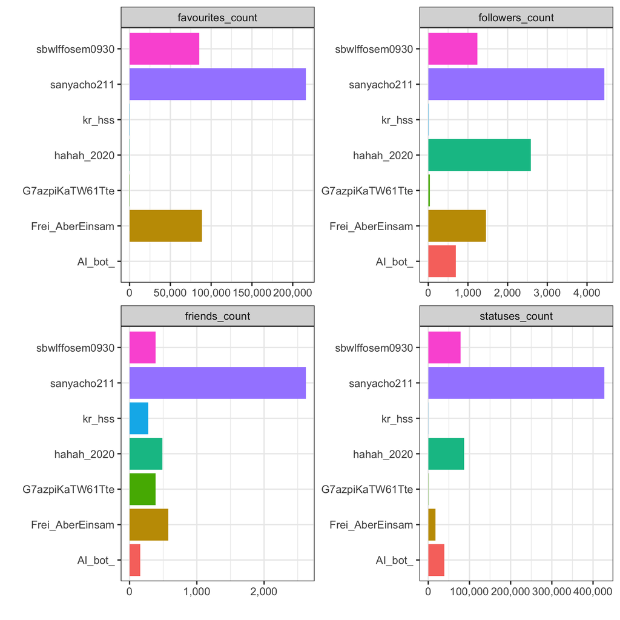

# 4 리트윗 네트워크 분석

특정 해쉬태그 관련 트윗 검색어를 넣어 `include_rts = TRUE` 리트윗을 추가하게 되면 리트윗(retweet) from, to 자료구조를 통해서 네트워크 분석을 통해서 트윗이 어떻게 전파되는지, 전파경로를 파악할 수 있다.

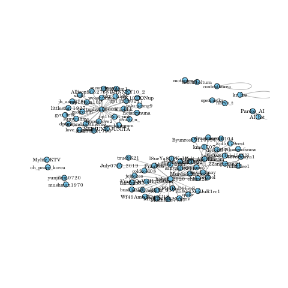

리트윗 네트워크 분석

# 5 공간정보

특정 해쉬태그 관련 트윗 검색어를 넣어 어디에서 많이 하는지 공간정보가 포함되어 있는 경우 이를 반영시킨다.

```r
library(rtweet)
library(leaflet)

geo_twts_df <- lat_lng(twit_df) %>%
  select(screen_name, text, lng, lat) %>%
  filter(!is.na(lng))


geo_twts_df %>%
  leaflet() %>%
  addProviderTiles(providers$OpenStreetMap) %>%
  addMarkers(lng=~lng, lat=~lat, clusterOptions = markerClusterOptions(),
             popup = ~ as.character(paste0("<strong>", paste0("유저명: ",`screen_name`), "</strong><br>",
                                           "-----------------------------------------------------------<br>",
                                           "&middot; 트윗: ", text)))
```

[interactive chart not shown]

# 6 트윗 텍스트 분석

특정 해쉬태그관련 트윗 검색어를 텍스트 데이터로 놓고 이를 자연어처리 분석을 추진한다. 이를 위해서 `tidytext` 팩키지를 통해 단어 토큰을 만들이고 불용어 처리한 후에 단어 빈도수를 시각화해 보자.

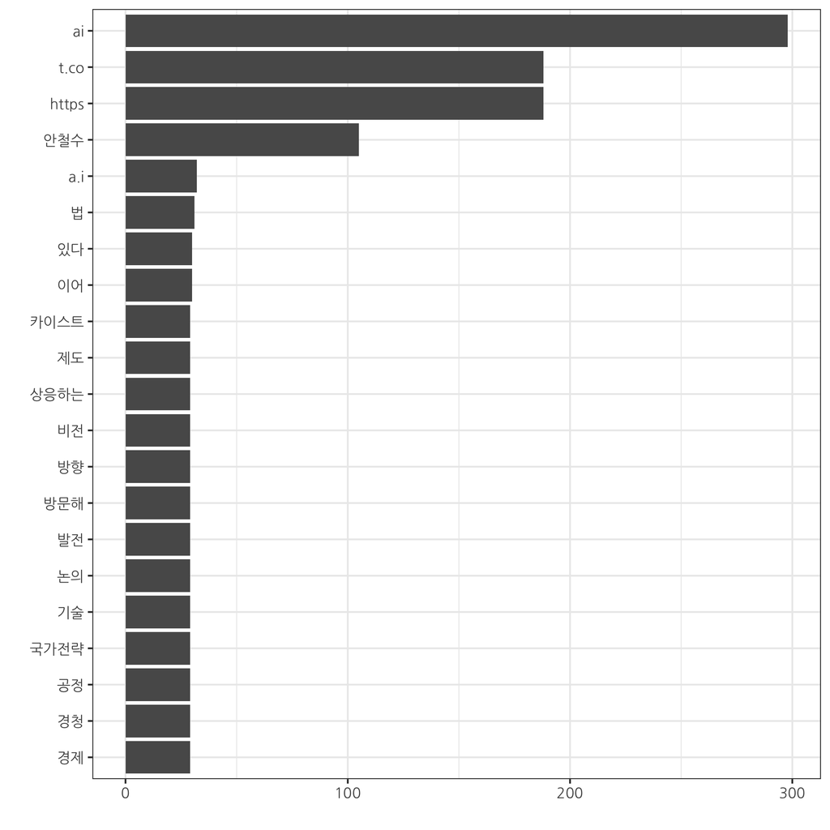

트윗 텍스트 분석